# practical_exercise_3, Methods 3, 2021, autumn semester

```r
summary(model_2.1)
```

```
## Linear mixed model fit by maximum likelihood . t-tests use Satterthwaite's
##   method [lmerModLmerTest]
## Formula: rt.obj ~ task + (1 | subject)
##    Data: exp
##
##      AIC      BIC   logLik deviance df.resid
##  61940.2  61977.4 -30965.1  61930.2    12523
##
## Scaled residuals:
##     Min      1Q  Median      3Q     Max
##  -0.630  -0.155  -0.072   0.051 101.443
##
## Random effects:
##  Groups   Name        Variance Std.Dev.
##  subject  (Intercept) 0.1147   0.3386
##  Residual             8.1739   2.8590
## Number of obs: 12528, groups:  subject, 29
##
## Fixed effects:
##                  Estimate Std. Error         df t value Pr(>|t|)
## (Intercept)     1.120e+00  7.689e-02  4.775e+01  14.568  < 2e-16 ***
## taskquadruplet -1.532e-01  6.257e-02  1.250e+04  -2.449  0.01433 *
## tasksingles    -1.915e-01  6.257e-02  1.250e+04  -3.061  0.00221 **
## ---
## Signif. codes:  0 '***' 0.001 '**' 0.01 '*' 0.05 '.' 0.1 ' ' 1
##
## Correlation of Fixed Effects:
##             (Intr) tskqdr
## taskqudrplt -0.407
## tasksingles -0.407  0.500
```

```
The model shows that reaction times are highest for pairs tasks, with somewhat lower reaction times for singles tasks and quadruplet tasks, p < .05.
```

3. Now add *pas* and its interaction with *task* to the fixed effects

```r
#When you want to model both main effects and their interactions, use an asterisk (*) between the effects. When you want to model ONLY the interaction, use a colon (:).
model_2.3 <- lmerTest::lmer(rt.obj ~ pas * task + (1 | subject), data = exp, REML = FALSE)
summary(model_2.3)
```

```
## Linear mixed model fit by maximum likelihood . t-tests use Satterthwaite's
##   method [lmerModLmerTest]
## Formula: rt.obj ~ pas * task + (1 | subject)
##    Data: exp
##
##      AIC      BIC   logLik deviance df.resid
##  61917.4  62021.5 -30944.7  61889.4    12514
##
## Scaled residuals:
##     Min      1Q  Median      3Q     Max
##  -0.667  -0.152  -0.064   0.047 101.556
##
## Random effects:
##  Groups   Name        Variance Std.Dev.
##  subject  (Intercept) 0.09749  0.3122
##  Residual             8.14982  2.8548
## Number of obs: 12528, groups:  subject, 29
##
## Fixed effects:
##                       Estimate Std. Error         df t value Pr(>|t|)
## (Intercept)          1.335e+00  9.786e-02  1.569e+02  13.644  < 2e-16 ***
## pas2                -1.394e-01  1.150e-01  1.228e+04  -1.213  0.22521
## pas3                -3.359e-01  1.314e-01  1.184e+04  -2.557  0.01058 *
## pas4                -5.795e-01  1.341e-01  9.034e+03  -4.321 1.57e-05 ***
## taskquadruplet      -3.229e-01  1.068e-01  1.251e+04  -3.023  0.00251 **
## tasksingles         -2.156e-01  1.155e-01  1.252e+04  -1.866  0.06205 .
## pas2:taskquadruplet  2.273e-01  1.582e-01  1.252e+04   1.437  0.15067
## pas3:taskquadruplet  2.624e-01  1.822e-01  1.252e+04   1.440  0.14979
## pas4:taskquadruplet  2.583e-01  1.797e-01  1.251e+04   1.437  0.15068
## pas2:tasksingles     1.251e-01  1.661e-01  1.253e+04   0.753  0.45131
## pas3:tasksingles     9.453e-02  1.852e-01  1.252e+04   0.510  0.60972
## pas4:tasksingles     7.097e-02  1.746e-01  1.252e+04   0.406  0.68444
## ---
## Signif. codes:  0 '***' 0.001 '**' 0.01 '*' 0.05 '.' 0.1 ' ' 1
##
## Correlation of Fixed Effects:
##             (Intr) pas2   pas3   pas4   tskqdr tsksng ps2:tskq ps3:tskq
## pas2        -0.553
## pas3        -0.499  0.425
## pas4        -0.504  0.414  0.395
## taskqudrplt -0.562  0.478  0.420  0.410
## tasksingles -0.517  0.441  0.386  0.373  0.474
## ps2:tskqdrp  0.378 -0.697 -0.282 -0.276 -0.677 -0.319
## ps3:tskqdrp  0.328 -0.280 -0.681 -0.238 -0.587 -0.279  0.397
## ps4:tskqdrp  0.333 -0.284 -0.249 -0.658 -0.595 -0.282  0.402    0.348
## ps2:tsksngl  0.368 -0.672 -0.279 -0.270 -0.330 -0.697  0.481    0.194
## ps3:tsksngl  0.327 -0.276 -0.677 -0.242 -0.296 -0.625  0.199    0.484
## ps4:tsksngl  0.343 -0.290 -0.255 -0.681 -0.314 -0.662  0.211    0.185
##             ps4:tskq ps2:tsks ps3:tsks
## pas2
## pas3
## pas4
## taskqudrplt
## tasksingles
## ps2:tskqdrp
## ps3:tskqdrp
## ps4:tskqdrp
## ps2:tsksngl  0.195
## ps3:tsksngl  0.176    0.437
## ps4:tsksngl  0.507    0.460    0.413
```

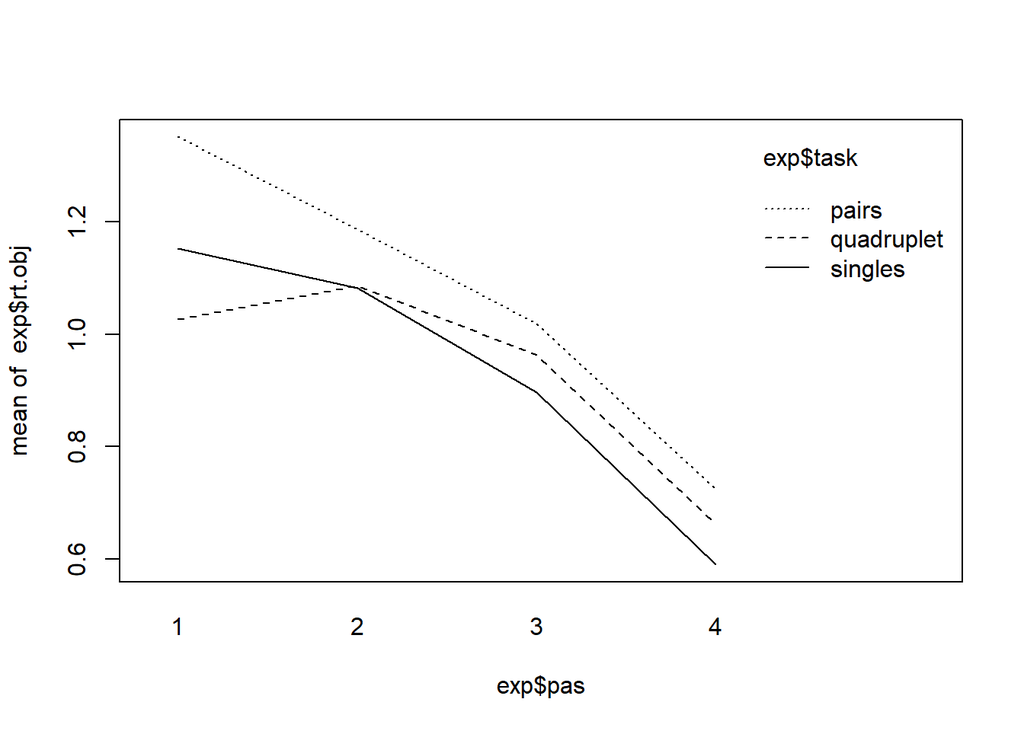

```r
interaction.plot(exp$pas, exp$task, exp$rt.obj) #plot the interaction to help me understand it better
```

```r
model_2.4 <- lmerTest::lmer(rt.obj ~ task + (1 | subject) + (1 | cue) + (1 | trial) + (1 | target.type) + (1 | pas), data = exp, REML = FALSE)
model_2.5 <- lmerTest::lmer(rt.obj ~ task + (1 | subject) + (1 | cue) + (1 | trial) + (1 | target.type) + (1 | pas) + (1 | task), data = exp, REML = FALSE)
```

```
## boundary (singular) fit: see ?isSingular
```

[output not shown]

```r
# I take the model with convergence issues from the previous exercise
print(VarCorr(model_2.5), comp = 'Variance')
```

```
##  Groups      Name        Variance
##  trial       (Intercept) 0.0020319
##  cue         (Intercept) 0.0957207
##  subject     (Intercept) 0.1000015
##  pas         (Intercept) 0.0347612
##  task        (Intercept) 0.0000000
##  target.type (Intercept) 0.0025884
##  Residual                8.1138210
```

[output not shown]

## Exercise 3

1. Initialise a new data frame, `data.count`. *count* should indicate the number of times they categorized their experience as *pas* 1-4 for each *task*. I.e. the data frame would have for subject 1: for task:singles, pas1 was used # times, pas2 was used # times, pas3 was used # times and pas4 was used # times. You would then do the same for task:pairs and task:quadruplet

```r
data.count <- df %>%
  group_by(subject, task, pas) %>%
  summarise('count' = n()) #create grouping data frame
data.count$subject <- as.factor(data.count$subject)
data.count$task <- as.factor(data.count$task)
data.count$pas <- as.factor(data.count$pas)
data.count$count <- as.integer(data.count$count) #ensure correct data format
```

2. Now fit a multilevel model that models a unique “slope” for *pas* for each *subject* with the interaction between *pas* and *task* and their main effects being modelled

```r
model_3.2 <- glmer(count ~ pas + task + pas:task + (1 + pas | subject),
                   data = data.count,
                   family = 'poisson',
                   control = glmerControl(optimizer = "bobyqa"))
summary(model_3.2)
```

```
## Generalized linear mixed model fit by maximum likelihood (Laplace
##   Approximation) [glmerMod]
##  Family: poisson  ( log )
## Formula: count ~ pas + task + pas:task + (1 + pas | subject)
##    Data: data.count
## Control: glmerControl(optimizer = "bobyqa")
##
##      AIC      BIC   logLik deviance df.resid
##   3148.4   3232.7  -1552.2   3104.4      318
##
## Scaled residuals:
##     Min      1Q  Median      3Q     Max
## -4.3871 -0.7853 -0.0469  0.7550  6.5438
##
## Random effects:
##  Groups  Name        Variance Std.Dev. Corr
##  subject (Intercept) 0.3324   0.5765
##          pas2        0.3803   0.6167   -0.75
##          pas3        1.1960   1.0936   -0.84  0.63
##          pas4        2.3736   1.5407   -0.86  0.42  0.72
## Number of obs: 340, groups:  subject, 29
##
## Fixed effects:
##                     Estimate Std. Error z value Pr(>|z|)
## (Intercept)          4.03570    0.10976  36.770  < 2e-16 ***
## pas2                -0.02378    0.11963  -0.199 0.842456
## pas3                -0.51365    0.20717  -2.479 0.013164 *
## pas4                -0.77292    0.29075  -2.658 0.007851 **
## taskquadruplet       0.11490    0.03127   3.674 0.000239 ***
## tasksingles         -0.23095    0.03418  -6.756 1.42e-11 ***
## pas2:taskquadruplet -0.11376    0.04605  -2.470 0.013508 *
## pas3:taskquadruplet -0.20902    0.05287  -3.954 7.69e-05 ***
## pas4:taskquadruplet -0.21500    0.05230  -4.111 3.94e-05 ***
## pas2:tasksingles     0.19536    0.04830   4.045 5.23e-05 ***
## pas3:tasksingles     0.24299    0.05369   4.526 6.02e-06 ***
## pas4:tasksingles     0.56346    0.05101  11.045  < 2e-16 ***
## ---
## Signif. codes:  0 '***' 0.001 '**' 0.01 '*' 0.05 '.' 0.1 ' ' 1
##
## Correlation of Fixed Effects:
```

[output cut: 9 more lines]

```
## ps2:tsksngl  0.098 -0.188 -0.052 -0.037 -0.342 -0.708  0.490    0.203
## ps3:tsksngl  0.088 -0.080 -0.124 -0.033 -0.308 -0.637  0.209    0.486
## ps4:tsksngl  0.092 -0.085 -0.049 -0.091 -0.324 -0.670  0.220    0.192
##             ps4:tskq ps2:tsks ps3:tsks
## pas2
## pas3
## pas4
## taskqudrplt
## tasksingles
## ps2:tskqdrp
## ps3:tskqdrp
## ps4:tskqdrp
## ps2:tsksngl  0.205
## ps3:tsksngl  0.184    0.451
## ps4:tsksngl  0.507    0.474    0.427
```

```
i. which family should be used?
A Poisson-distribution should be used as we are investigating count data for specific units of measurement.
HOWEVER:
```

```r
mean(data.count$count)
```

```
## [1] 53.32647
```

```r
var(data.count$count)
```

```
## [1] 1214.002
```

[output not shown]

```r
model_3.2b <- glmer(count ~ pas + task + (1 + pas | subject),
                    data = data.count,
                    family = 'poisson',
                    control = glmerControl(optimizer = "bobyqa"))
summary(model_3.2b)
```

```
## Generalized linear mixed model fit by maximum likelihood (Laplace
##   Approximation) [glmerMod]
##  Family: poisson  ( log )
## Formula: count ~ pas + task + (1 + pas | subject)
##    Data: data.count
## Control: glmerControl(optimizer = "bobyqa")
##
##      AIC      BIC   logLik deviance df.resid
##   3398.5   3459.8  -1683.3   3366.5      324
##
## Scaled residuals:
##     Min      1Q  Median      3Q     Max
## -5.5885 -0.9001 -0.0477  0.8253  6.5100
##
## Random effects:
##  Groups  Name        Variance Std.Dev. Corr
##  subject (Intercept) 0.3325   0.5766
##          pas2        0.3805   0.6169   -0.75
##          pas3        1.1895   1.0906   -0.84  0.63
##          pas4        2.4221   1.5563   -0.86  0.42  0.73
## Number of obs: 340, groups:  subject, 29
##
## Fixed effects:
##                 Estimate Std. Error z value Pr(>|z|)
## (Intercept)     4.004594   0.108722  36.833   <2e-16 ***
## pas2           -0.006531   0.116615  -0.056   0.9553
## pas3           -0.509923   0.204448  -2.494   0.0126 *
## pas4           -0.663848   0.291955  -2.274   0.0230 *
## taskquadruplet  0.003294   0.018188   0.181   0.8563
## tasksingles     0.004307   0.018177   0.237   0.8127
## ---
## Signif. codes:  0 '***' 0.001 '**' 0.01 '*' 0.05 '.' 0.1 ' ' 1
##
## Correlation of Fixed Effects:
##             (Intr) pas2   pas3   pas4   tskqdr
## pas2        -0.742
## pas3        -0.832  0.623
## pas4        -0.850  0.412  0.723
## taskqudrplt -0.084  0.000  0.001 -0.002
## tasksingles -0.084  0.000  0.000  0.000  0.501
```

```
v. indicate which of the two models, you would choose and why
```

```r
# AIC comparison:
AIC(model_3.2, model_3.2b)
```

```
##            df      AIC
## model_3.2  22 3148.441
## model_3.2b 16 3398.549
```

```r
# Residual variance (using formula):
c(var(residuals(model_3.2)),
  var(residuals(model_3.2b))
)
```

```
## [1] 2.055365 2.828064
```

```r
# Residual standard deviation (using formula):
c(sd(residuals(model_3.2)),
  sd(residuals(model_3.2b))
)
```

```
## [1] 1.433654 1.681685
```

```
When checking AIC scores, residual variance and standard deviation, the model _with_ interactions appears better.
vi. based on your chosen model - write a short report on what this says about the distribution of ratings as dependent on _pas_ and _task_
```

```r
#When you want to interpret the output of a Poisson regression, you have to take the exp() of output. In order to not have a mental breakdown, let's collect it into a handy table:
normal <- fixef(model_3.2)
exp <- exp(fixef(model_3.2))
poisson <- as.data.frame(cbind(normal, exp))

#If the value is negative, it implies a decrease, and the exponentiated value has to be subtracted from 1
poisson$corrected <- ifelse((poisson$normal < 0), 1 - poisson$exp, poisson$exp)
poisson$direction <- ifelse((poisson$normal < 0), "decrease", "increase")

poisson
```

```
##                          normal        exp   corrected direction
## (Intercept)          4.03570123 56.5825836 56.58258362  increase
## pas2                -0.02377598  0.9765044  0.02349556  decrease
## pas3                -0.51364811  0.5983089  0.40169110  decrease
## pas4                -0.77292326  0.4616615  0.53833846  decrease
## taskquadruplet       0.11490066  1.1217620  1.12176199  increase
## tasksingles         -0.23094567  0.7937826  0.20621741  decrease
## pas2:taskquadruplet -0.11375513  0.8924765  0.10752353  decrease
## pas3:taskquadruplet -0.20901514  0.8113830  0.18861705  decrease
## pas4:taskquadruplet -0.21500491  0.8065375  0.19346252  decrease
## pas2:tasksingles     0.19536301  1.2157522  1.21575224  increase
## pas3:tasksingles     0.24299389  1.2750608  1.27506084  increase
## pas4:tasksingles     0.56346179  1.7567435  1.75674346  increase
```

[output not shown]

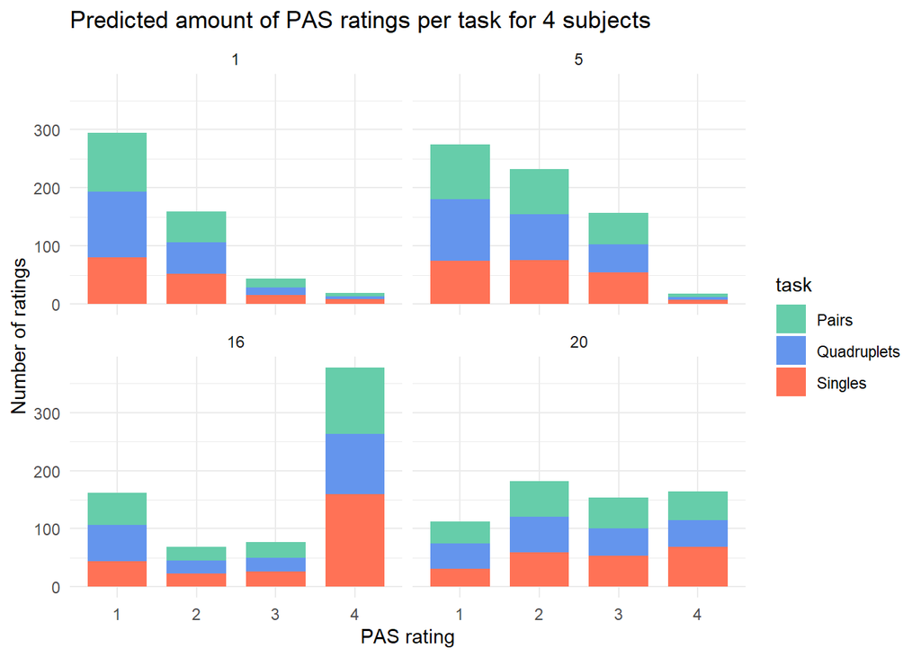

```r
# When making predictions from a regression model, we can make either in-sample or out-of-sample predictions.
# When making in-sample predictions, we basically obtain the predicted values for the y axis based on the existing values on the x axis; i.e. the value on y if there was no error. These are the fitted values.
# Since we are trying to estimate ratings for subjects already in the dataset, we make in-sample predictions.

#Extract the fitted values
data.count$fitted <- fitted(model_3.2)

#Select subjects
df_3.2 <- data.count %>%
  filter(subject == '1' | subject == '5' | subject == '16' | subject == '20')

ggplot(data = df_3.2, aes(x = pas, y = fitted, fill = task)) +
  geom_col(width = 0.75) +
  facet_wrap(~subject) +
  labs(title = "Predicted amount of PAS ratings per task for 4 subjects", x = "PAS rating", y = "Number of ratings") +
  scale_fill_manual(labels = c("Pairs", "Quadruplets", "Singles"), values = c("aquamarine3", "cornflowerblue", "coral1")) +
  guides(color = guide_legend("Task")) +
  theme_minimal()
```

3) Finally, fit a multilevel model that models *correct* as dependent on *task* with a unique intercept for each *subject*

```r
model_3.3a <- glmer(correct ~ task + (1 | subject), family = 'binomial', data = df)
summary(model_3.3a)
```

```
## Generalized linear mixed model fit by maximum likelihood (Laplace
##   Approximation) [glmerMod]
##  Family: binomial  ( logit )
## Formula: correct ~ task + (1 | subject)
##    Data: df
##
##      AIC      BIC   logLik deviance df.resid
##  19927.2  19958.4  -9959.6  19919.2    18127
##
## Scaled residuals:
##     Min      1Q  Median      3Q     Max
## -2.7426 -1.0976  0.5098  0.6101  0.9111
##
## Random effects:
##  Groups  Name        Variance Std.Dev.
##  subject (Intercept) 0.1775   0.4214
## Number of obs: 18131, groups:  subject, 29
##
## Fixed effects:
##                Estimate Std. Error z value Pr(>|z|)
## (Intercept)     1.10071    0.08386  13.125  < 2e-16 ***
## taskquadruplet -0.09825    0.04190  -2.345    0.019 *
## tasksingles     0.18542    0.04337   4.276 1.91e-05 ***
## ---
## Signif. codes:  0 '***' 0.001 '**' 0.01 '*' 0.05 '.' 0.1 ' ' 1
##
## Correlation of Fixed Effects:
##             (Intr) tskqdr
## taskqudrplt -0.256
## tasksingles -0.247  0.495
```

```
i. does _task_ explain performance?
ii. add _pas_ as a main effect on top of _task_ - what are the consequences of that?
```

```r
model_3.3b <- glmer(correct ~ task + pas + (1 | subject), family = 'binomial', data = df)
summary(model_3.3b)
```

```
## Generalized linear mixed model fit by maximum likelihood (Laplace
##   Approximation) [glmerMod]
##  Family: binomial  ( logit )
## Formula: correct ~ task + pas + (1 | subject)
##    Data: df
##
##      AIC      BIC   logLik deviance df.resid
##  17424.9  17479.5  -8705.5  17410.9    18124
##
## Scaled residuals:
##     Min      1Q  Median      3Q     Max
## -8.4872 -0.6225  0.3240  0.5767  1.6144
##
## Random effects:
##  Groups  Name        Variance Std.Dev.
##  subject (Intercept) 0.1979   0.4449
## Number of obs: 18131, groups:  subject, 29
##
## Fixed effects:
##                Estimate Std. Error z value Pr(>|z|)
## (Intercept)     0.08530    0.09143   0.933    0.351
## taskquadruplet -0.03055    0.04497  -0.679    0.497
## tasksingles    -0.01059    0.04687  -0.226    0.821
## pas2            0.95477    0.04419  21.604   <2e-16 ***
## pas3            1.97709    0.06219  31.793   <2e-16 ***
## pas4            3.12732    0.08626  36.255   <2e-16 ***
## ---
## Signif. codes:  0 '***' 0.001 '**' 0.01 '*' 0.05 '.' 0.1 ' ' 1
##
## Correlation of Fixed Effects:
##             (Intr) tskqdr tsksng pas2   pas3
## taskqudrplt -0.259
## tasksingles -0.225  0.489
## pas2        -0.212  0.021 -0.040
## pas3        -0.165  0.030 -0.045  0.355
## pas4        -0.123  0.016 -0.080  0.257  0.236
```

```
iii. now fit a multilevel model that models _correct_ as dependent on _pas_ with a unique intercept for each _subject_
```

```r
model_3.3c <- glmer(correct ~ pas + (1 | subject), family = 'binomial', data = df)
summary(model_3.3c)
```

```
## Generalized linear mixed model fit by maximum likelihood (Laplace
##   Approximation) [glmerMod]
##  Family: binomial  ( logit )
## Formula: correct ~ pas + (1 | subject)
##    Data: df
##
##      AIC      BIC   logLik deviance df.resid
##  17421.4  17460.4  -8705.7  17411.4    18126
##
## Scaled residuals:
##     Min      1Q  Median      3Q     Max
## -8.5665 -0.6243  0.3244  0.5754  1.6017
##
## Random effects:
##  Groups  Name        Variance Std.Dev.
##  subject (Intercept) 0.1981   0.4451
## Number of obs: 18131, groups:  subject, 29
##
## Fixed effects:
##             Estimate Std. Error z value Pr(>|z|)
## (Intercept)  0.07044    0.08773   0.803    0.422
## pas2         0.95575    0.04410  21.671   <2e-16 ***
## pas3         1.97892    0.06201  31.914   <2e-16 ***
## pas4         3.12940    0.08579  36.476   <2e-16 ***
## ---
## Signif. codes:  0 '***' 0.001 '**' 0.01 '*' 0.05 '.' 0.1 ' ' 1
##
## Correlation of Fixed Effects:
##      (Intr) pas2   pas3
## pas2 -0.223
## pas3 -0.173  0.352
## pas4 -0.136  0.253  0.231
```

```
iv. finally, fit a model that models the interaction between _task_ and _pas_  and their main effects
```

```r
model_3.3d <- glmer(correct ~ task * pas + (1 | subject), family = 'binomial', data = df)
summary(model_3.3d)
```

```
## Generalized linear mixed model fit by maximum likelihood (Laplace
##   Approximation) [glmerMod]
##  Family: binomial  ( logit )
## Formula: correct ~ task * pas + (1 | subject)
##    Data: df
##
##      AIC      BIC   logLik deviance df.resid
##  17431.0  17532.4  -8702.5  17405.0    18118
##
## Scaled residuals:
##     Min      1Q  Median      3Q     Max
## -7.9329 -0.6276  0.3186  0.5750  1.6411
##
## Random effects:
##  Groups  Name        Variance Std.Dev.
##  subject (Intercept) 0.1987   0.4458
## Number of obs: 18131, groups:  subject, 29
##
## Fixed effects:
##                      Estimate Std. Error z value Pr(>|z|)
## (Intercept)          0.083724   0.095677   0.875    0.382
## taskquadruplet       0.006494   0.064352   0.101    0.920
## tasksingles         -0.058974   0.070459  -0.837    0.403
## pas2                 0.963211   0.073725  13.065   <2e-16 ***
## pas3                 1.999940   0.102926  19.431   <2e-16 ***
## pas4                 3.049626   0.145543  20.953   <2e-16 ***
## taskquadruplet:pas2 -0.049301   0.100765  -0.489    0.625
## tasksingles:pas2     0.040480   0.105998   0.382    0.703
## taskquadruplet:pas3 -0.134128   0.142258  -0.943    0.346
## tasksingles:pas3     0.079972   0.145297   0.550    0.582
## taskquadruplet:pas4 -0.095815   0.199830  -0.479    0.632
## tasksingles:pas4     0.296561   0.196610   1.508    0.131
## ---
## Signif. codes:  0 '***' 0.001 '**' 0.01 '*' 0.05 '.' 0.1 ' ' 1
##
## Correlation of Fixed Effects:
##             (Intr) tskqdr tsksng pas2   pas3   pas4   tskq:2 tsks:2 tskq:3
## taskqudrplt -0.357
## tasksingles -0.323  0.481
## pas2        -0.329  0.464  0.420
## pas3        -0.242  0.332  0.298  0.322
## pas4        -0.175  0.235  0.206  0.224  0.177
## tskqdrplt:2  0.227 -0.639 -0.306 -0.704 -0.211 -0.149
## tsksngls:p2  0.220 -0.321 -0.665 -0.676 -0.209 -0.146  0.487
## tskqdrplt:3  0.161 -0.451 -0.217 -0.211 -0.695 -0.105  0.288  0.145
## tsksngls:p3  0.157 -0.232 -0.484 -0.204 -0.681 -0.104  0.147  0.323  0.490
## tskqdrplt:4  0.114 -0.321 -0.153 -0.147 -0.105 -0.698  0.205  0.102  0.144
## tsksngls:p4  0.114 -0.171 -0.357 -0.147 -0.103 -0.706  0.109  0.237  0.077
##             tsks:3 tskq:4
## taskqudrplt
## tasksingles
## pas2
## pas3
## pas4
## tskqdrplt:2
## tsksngls:p2
## tskqdrplt:3
## tsksngls:p3
## tskqdrplt:4  0.074
## tsksngls:p4  0.172  0.515
```

```
v. describe in your words which model is the best in explaining the variance in accuracy
```

```r
#Residual variance:
c(var(residuals(model_3.3a)),
  var(residuals(model_3.3b)),
  var(residuals(model_3.3c)),
  var(residuals(model_3.3d))
)
```

```
## [1] 1.0704429 0.9386723 0.9386966 0.9383736
```

```r
#AIC
anova(model_3.3a, model_3.3b, model_3.3c, model_3.3d, test = 'LR')
```

```
## Data: df
## Models:
## model_3.3a: correct ~ task + (1 | subject)
## model_3.3c: correct ~ pas + (1 | subject)
## model_3.3b: correct ~ task + pas + (1 | subject)
## model_3.3d: correct ~ task * pas + (1 | subject)
##            npar   AIC   BIC  logLik deviance     Chisq Df Pr(>Chisq)
## model_3.3a    4 19927 19958 -9959.6    19919
## model_3.3c    5 17421 17460 -8705.7    17411 2507.8224  1     <2e-16 ***
## model_3.3b    7 17425 17480 -8705.5    17411    0.4759  2     0.7883
## model_3.3d   13 17431 17532 -8702.5    17405    5.9376  6     0.4302
## ---
## Signif. codes:  0 '***' 0.001 '**' 0.01 '*' 0.05 '.' 0.1 ' ' 1
```